# Rb-Sr calibration, validation, and uncertainty propagation

This code was used for matrix-matched calibration of the Rb–Sr data, age calculations, uncertainty propagation, and validation

Load the data exported from iolite:

```r
s1_df <- read_csv("data/RbSr_session1.csv")
s2_df <- read_csv("data/RbSr_session2_90um.csv")
```

The uncertainties on these values are common to all measurement sessions. The error on the Rb/Sr reference value cancels during the matrix correction.

```r
# NIST610 (primary RM) values from Rösel & Zack (2022)
NIST610_RbSr_REF_VAL <- list(value = 2.33, err_2se = 0.0049)
NIST610_SrSr_REF_VAL <- list(value = 0.709699, err_2se = 0.000018)

# MSG (matrix correction RM) long term variance (estimate after Rosel & Zack, 2022)
MCRM_LONG_TERM_VAR <- 0.02 # 2%

# decay constant for 87Rb (Villa et al., 2015)
LAMBDA_Rb <- list(value = 1.3972e-11, err_2se = 0.0045e-11)
```

Helper Functions

```r
# the column names which IsoplotR needs
Rb_Sr_cols <- c(
  "StdCorr_Rb87_Sr86s_mean",
  "StdCorr_Rb87_Sr86s_2SE(int)",
  "StdCorr_Sr87s_Sr86s_mean",
  "StdCorr_Sr87s_Sr86s_2SE(int)",
  "87Rb/86Sr - 87Sr/86Sr Rho"
)
Rb_Sr_cols_calibrated <- Rb_Sr_cols
Rb_Sr_cols_calibrated[1] <- "StdCorr_Rb87_Sr86s_mean_calibr"

filter_data <- function(df, spot_id_prefix) {
  df %>% filter(startsWith(spot_id, spot_id_prefix))
}

omitted_spots <- readLines("data/omitted_spots.txt")

fit_rm_isochron <- function(df, sr0 = NULL, inverse = FALSE, color = "#4e79a7", use_calibrated = FALSE) {

  if(use_calibrated) {
    cols <- Rb_Sr_cols_calibrated
  } else {
    cols <- Rb_Sr_cols
  }

  data <- IsoplotR::read.data(df[cols], method = "Rb-Sr", format = 1, ierr = 2)

  anchor <- FALSE
  if (!is.null(sr0)) {
    IsoplotR::settings("iratio", "Sr87Sr86", sr0$value, sr0$err_2se)
    anchor <- TRUE
  }

  IsoplotR::isochron(
    data,
    inverse = inverse, title = FALSE,
    oerr = 2, exterr = FALSE, # xlim=c(0,200), ylim=c(0.5,2),
    ellipse.fill = paste(color, "80", sep = ""),
    ellipse.stroke = NA,
    omit = which(df$spot_id %in% omitted_spots),
    omit.fill = NA, omit.stroke = color,
    tck = 0.02, las = 1, xaxs = "i", yaxs = "i",
    anchor = ifelse(anchor, 1, 0)
  )
}

calculate_correction_factor <- function(measured_age, ref_age) {
  measured_age / ref_age
}

apply_correction_factor <- function(df, corr_factor) {
  df <- df %>% mutate(
    StdCorr_Rb87_Sr86s_mean_calibr = StdCorr_Rb87_Sr86s_mean * corr_factor
  )
}
```

## Shap granite

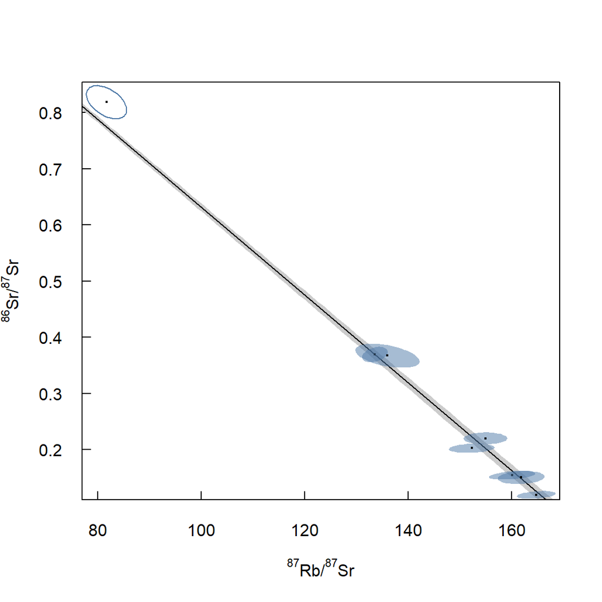

```r
sg_df <- filter_data(s1_df, "SG2_Bt")
#pdf("Shap_bt_isochron.pdf", width = cm(4), height = cm(4))
sg_fit <- fit_rm_isochron(sg_df, sr0 = list(value = 0.70756, err_2se = 0.00004), inverse = TRUE)
```

| SG-2 (biotite only) |  |
| --- | --- |
| age (NIST-calibrated) | 395 ± 4 Ma |
| (<sup>87</sup>Sr/<sup>86</sup>Sr)<sub>0</sub> | 0.7076 ± 0.0001 |
| MSWD | 0.69 |
| p(χ2) | 0.68 |

Using a reference age of **397.2 ± 2.3** (Bevan et al., 2021, JAAS), calculate the correction factor to apply to MSG biotite:

```r
msg_bt_corr_factor <- calculate_correction_factor(sg_fit$age[1], 397.2)
```

Shap-based correction factor for biotite is **0.9938831**.

## Recalculate Mountsorrel granodiorite (Cribb, 1975)

Data from Cribb (1975) Table 1. Errors are quoted at the 2s level.

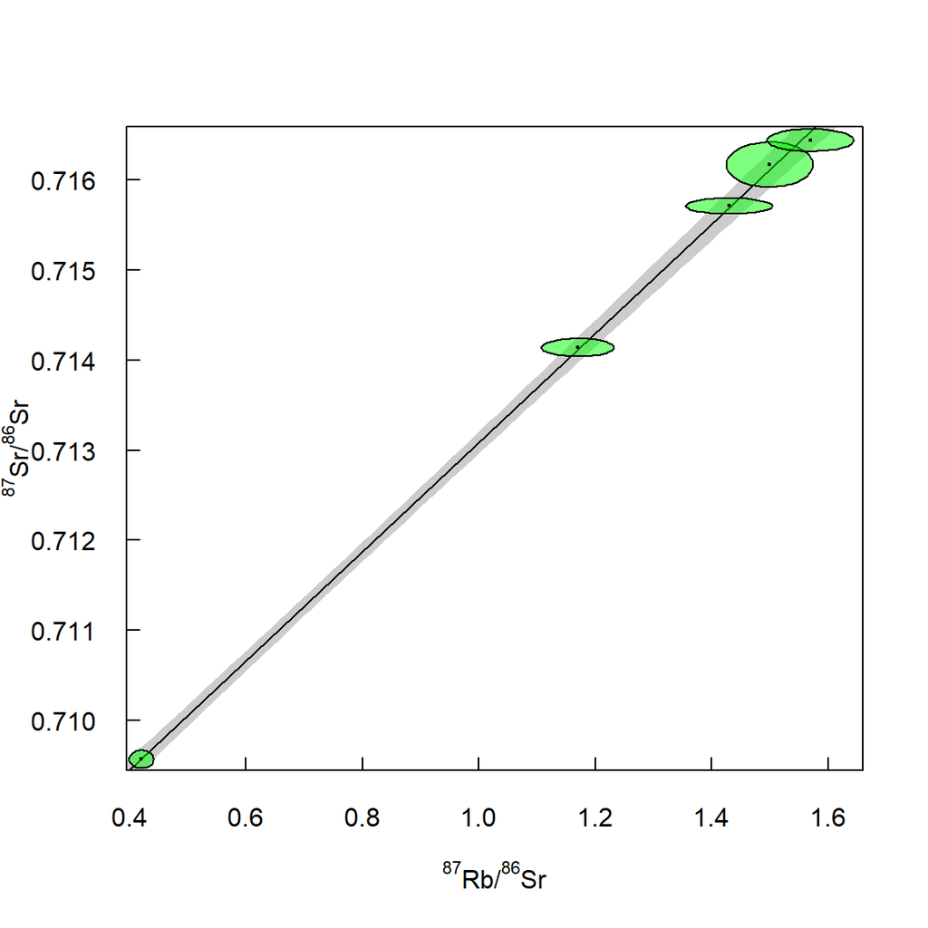

```r
cribb_df <- read_csv("data/Cribb_Tbl_1.csv")

cribb_df <- cribb_df %>%
  select(Rb87_Sr86, Rb87_Sr86_err2s, Sr87s_Sr86, Sr87s_Sr86_err2s)

cribb_obj <- IsoplotR::read.data(cribb_df, method = "Rb-Sr", format = 1, ierr = 2)

cribb_fit <- IsoplotR::isochron(
  cribb_obj,
  oerr = 2, exterr = TRUE, title = FALSE,
  tck = 0.02, las = 1, xaxs = "i", yaxs = "i"
)
```

```r
cribb_r_age <- list(value = cribb_fit$age[1], err_2se = cribb_fit$age[2] * 2)
cribb_r_sr0 <- list(value = cribb_fit$y0[1], err_2se = cribb_fit$y0[2] * 2)
```

| Recalculated Mountsorrel granodiorite |  |
| --- | --- |
| age | 432 ± 16 Ma |
| (<sup>87</sup>Sr/<sup>86</sup>Sr)<sub>0</sub> | 0.7070 ± 0.0002 |
| MSWD | 0.13 |
| p(χ2) | 0.94 |

## MSG age from Plag-Biotite (this study)

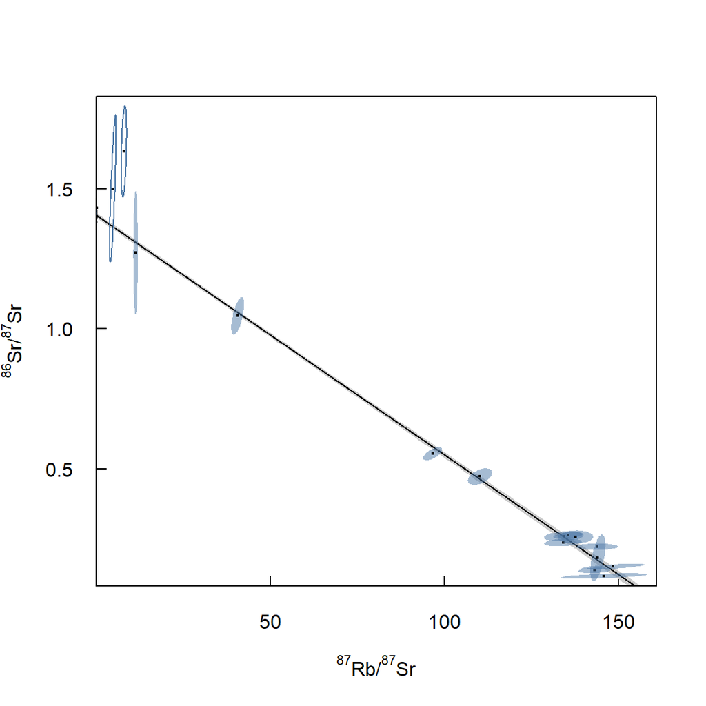

```r
msg_bt_df <- bind_rows(
  filter_data(s1_df, "MSG_Plag"),
  filter_data(s1_df, "MSG_Bt"),
  filter_data(s2_df, "MSG_Plag"),
  filter_data(s2_df, "MSG_Bt")
)

msg_bt_df <- apply_correction_factor(msg_bt_df, msg_bt_corr_factor)
#pdf("MSG_isochron.pdf", width = cm(4), height = cm(4))
msg_bt_fit <- fit_rm_isochron(msg_bt_df, inverse = TRUE, use_calibrated = TRUE)
```

```r
msg_bt_ext2se <- msg_bt_fit$age[1] * sqrt(
  + (msg_bt_fit$age[2] * 2 / msg_bt_fit$age[1])^2
  + (NIST610_SrSr_REF_VAL$err_2se / NIST610_SrSr_REF_VAL$value)^2
  + (2.3 / 397.2)^2 # Shap ref age
  + (sg_fit$age[2] * 2 / sg_fit$age[1])^2 # Shap measured age
  + 0.01^2 # estimated long term variance of Shap granite
  + (LAMBDA_Rb$err_2se / LAMBDA_Rb$value)^2
)

msg_bt_age <- list(value = msg_bt_fit$age[1], err_2se = msg_bt_ext2se)
msg_bt_sr0 <- list(value = msg_bt_fit$y0[1], err_2se = msg_bt_fit$y0[2] * 2)
```

| MSG (Plagioclase-biotite) |  |
| --- | --- |
| age (SG-2-calibrated) ± 2SE (external) | 435 ± 8 Ma |
| (<sup>87</sup>Sr/<sup>86</sup>Sr)<sub>0</sub> | 0.7114 ± 0.0046 |
| MSWD | 1.13 |
| p(χ2) | 0.3 |

The uncertainties on the age from the plagioclase–biotite isochron from this analysis are lower than Cribb (1975) but the initial Sr/Sr uncertainties are lower in Cribb (1975). Use the values with the lowest uncertainties:

```r
MCRM_REF_AGE <- msg_bt_age
MCRM_REF_Sr0 <- cribb_r_sr0
```

## External error propagation functions

```r
get_session_ext_2rs_sq <- function(mcrm_meas_age) {
  (mcrm_meas_age$age[2] * 2 / mcrm_meas_age$age[1])^2
}

get_common_syst_errs_sum_of_sq <- function() {
  return(
    (NIST610_SrSr_REF_VAL$err_2se / NIST610_SrSr_REF_VAL$value)^2
      + (MCRM_REF_AGE$err_2se / MCRM_REF_AGE$value)^2
      + MCRM_LONG_TERM_VAR^2
      + (LAMBDA_Rb$err_2se / LAMBDA_Rb$value)^2
  )
}

append_ext_2rs <- function(df, mcrm_meas_age, session) {
  df <- df %>% mutate(
    ext_sys_errs_2rs_partial_sum_sq = get_session_ext_2rs_sq(mcrm_meas_age)
    + get_common_syst_errs_sum_of_sq(),
    session = session
  )
}

prop_ext_errs <- function(value, internal_2s, ext_errs_partial_sum) {
  return(value * sqrt((internal_2s / value)^2 + ext_errs_partial_sum))
}
```

## Session 1

Session 1 (2 Feb 2024) included 167 feldspar unknowns + 47 reference materials (NIST610, NIST607 NP, FK-N NP, Mica-Mg NP) + 90 calibration/validation spots on SG-2 (Shap) and MSG (Mountsorrel) granites.

### S1 NIST-calibrated age, Mountsorrel

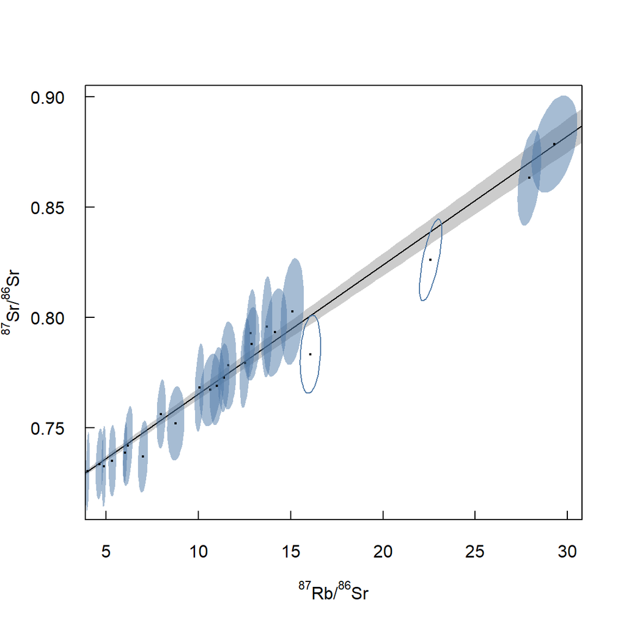

```r
s1_msg_kfs_df <- filter_data(s1_df, "MSG_Kfs")
s1_msg_fit <- fit_rm_isochron(s1_msg_kfs_df, sr0 = MCRM_REF_Sr0)
```

### S1 correction factor

| Session 1 MSG (K-feldspar only) |  |
| --- | --- |
| age (NIST-calibrated) ± 2SE (internal) | 417 ± 18 Ma |
| (<sup>87</sup>Sr/<sup>86</sup>Sr)<sub>0</sub> | 0.7070 ± 0.0004 |
| MSWD | 0.48 |
| p(χ2) | 0.98 |

Using a reference age of **435 ± 8 Ma** (calculated above), calculate the correction factor to apply to K-feldspar unknowns:

```r
s1_corr_factor <- calculate_correction_factor(s1_msg_fit$age[1], MCRM_REF_AGE$value)
```

Session 1 correction factor is **0.9600529**.

### S1 calibration of unknowns

```r
s1_unknowns_df <- filter_data(s1_df, spot_id_prefix = "GM")
s1_unknowns_df <- apply_correction_factor(s1_unknowns_df, s1_corr_factor)
```

### S1 calculate uncertainties

store in the unknowns table to apply to the final age, once calculated.

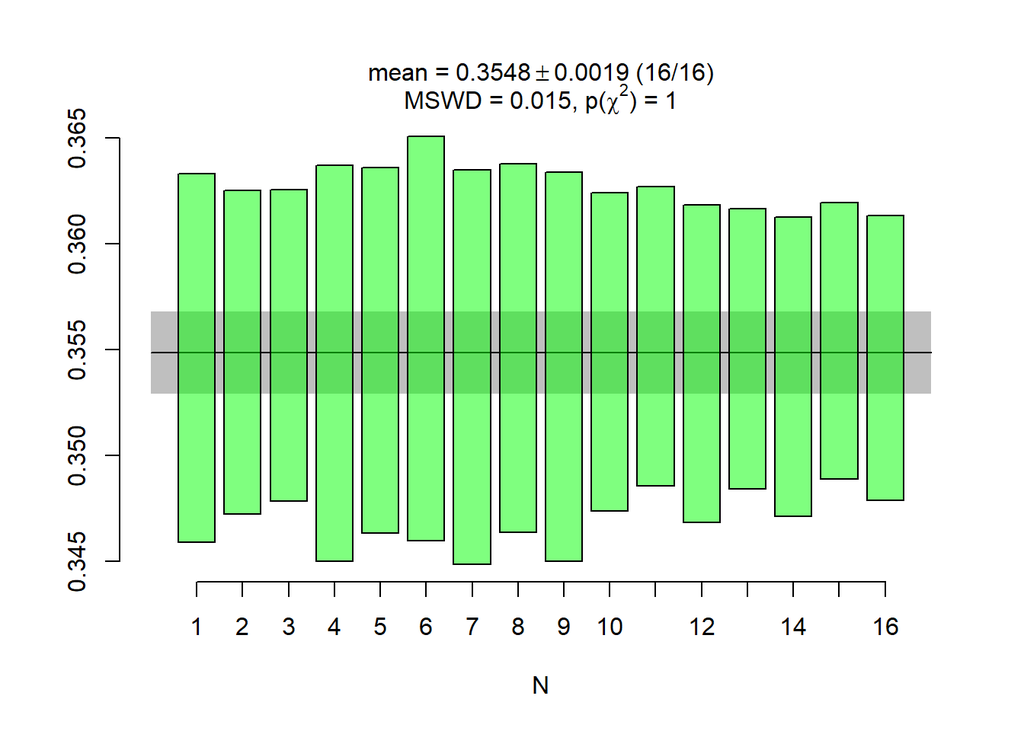

```r
# NIST610 (primary RM)
s1_NIST610 <- filter_data(s1_df, "NIST610")
s1_NIST610_SrSr <- IsoplotR::weightedmean(as.matrix(s1_NIST610[, c("StdCorr_Sr87s_Sr86s_mean", "StdCorr_Sr87s_Sr86s_2SE(int)")]) / 2, oerr = 2)
```

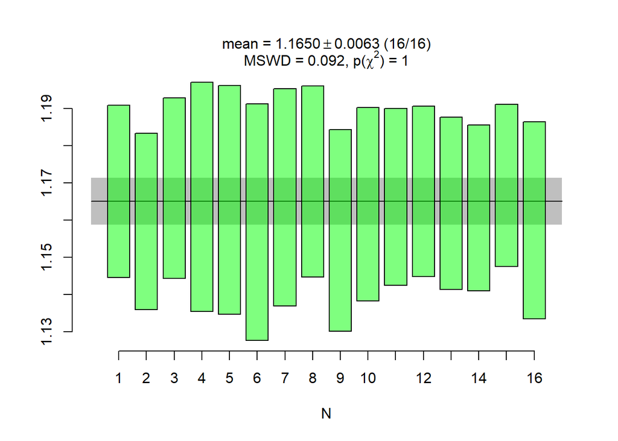

```r
s1_NIST610_RbSr <- IsoplotR::weightedmean(as.matrix(s1_NIST610[, c("StdCorr_Rb87_Sr86s_mean", "StdCorr_Rb87_Sr86s_2SE(int)")]) / 2, oerr = 2)
```

Check that the MSWD for the primary RM is <1 and therefore no propagation of the excess variance is needed:

MSWD 87/86Sr = 0.0152385

MSWD 87Rb/86Sr = 0.0923257

```r
# add the systematic uncertainty of the measured MCRM age to the other systematic uncertainties
s1_unknowns_df <- append_ext_2rs(s1_unknowns_df, s1_msg_fit, session = 1)
```

## Session 2

Session 2 (7 May 2024) included 288 feldspar unknowns + 49 reference materials (NIST610, BCR-2G) + 109 calibration/validation spots on SG-2 (Shap), MSG (Mountsorrel), and HG-1 (Haytor/Dartmoor) granites.

### S2 NIST-calibrated age, Mountsorrel

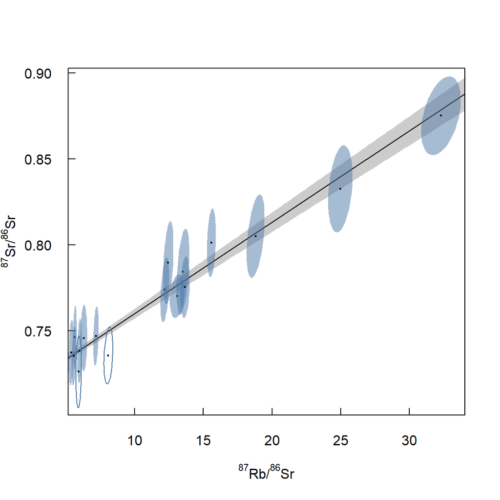

```r
s2_msg_kfs_df <- filter_data(s2_df, "MSG_Kfs")
s2_msg_fit <- fit_rm_isochron(s2_msg_kfs_df, sr0 = MCRM_REF_Sr0)
```

### S2 correction factor

| Session 2 MSG (K-feldspar only) |  |
| --- | --- |
| age (NIST-calibrated) ± 2SE (internal) | 379 ± 20 Ma |
| (<sup>87</sup>Sr/<sup>86</sup>Sr)<sub>0</sub> | 0.7070 ± 0.0004 |
| MSWD | 0.7 |
| p(χ2) | 0.79 |

Using a reference age of **435 ± 8 Ma** (calculated above), calculate the correction factor to apply to K-feldspar unknowns:

```r
s2_corr_factor <- calculate_correction_factor(s2_msg_fit$age[1], MCRM_REF_AGE$value)
```

Session 2 correction factor is **0.8728949**.

### S2 calibration of unknowns

```r
s2_unknowns_df <- filter_data(s2_df, spot_id_prefix = "GM")
s2_unknowns_df <- apply_correction_factor(s2_unknowns_df, s2_corr_factor)
```

### S2 calculate uncertainties

store in the unknowns table to apply to the final age, once calculated.

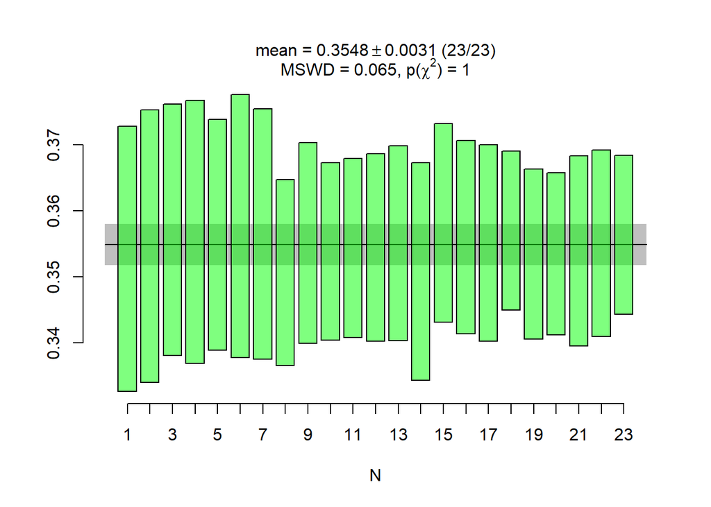

```r
# NIST610 (primary RM)
s2_NIST610 <- filter_data(s2_df, "NIST610")
s2_NIST610_SrSr <- IsoplotR::weightedmean(as.matrix(s2_NIST610[, c("StdCorr_Sr87s_Sr86s_mean", "StdCorr_Sr87s_Sr86s_2SE(int)")]) / 2, oerr = 2)
```

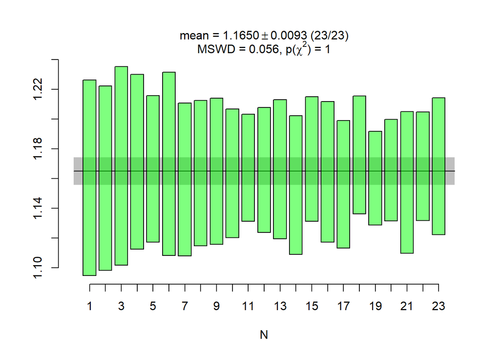

```r
s2_NIST610_RbSr <- IsoplotR::weightedmean(as.matrix(s2_NIST610[, c("StdCorr_Rb87_Sr86s_mean", "StdCorr_Rb87_Sr86s_2SE(int)")]) / 2, oerr = 2)
```

Check that the MSWD for the primary RM is <1 and therefore no propagation of the excess variance is needed:

MSWD 87/86Sr = 0.0649386

MSWD 87Rb/86Sr = 0.0558695

```r
# add the systematic uncertainty of the measured MCRM age to the other systematic uncertainties
s2_unknowns_df <- append_ext_2rs(s2_unknowns_df, s2_msg_fit, session = 2)

rb_sr_df <- bind_rows(s1_unknowns_df, s2_unknowns_df)
```

## Merge with Pb groups

```r
Pb_group_mapping <- read_csv("data/Kfs_Pb_groups.csv")
Pb_group_mapping <- Pb_group_mapping %>%
  mutate(
    grain_name = sub("(.*_.*)_#\\d(\\d{4})", "\\1_#0\\2", spot_id),
  ) %>%
  select(-spot_id)

rb_sr_df <- rb_sr_df %>%
  mutate(
    grain_name = sub("(.*_.*)_#\\d(\\d{4})", "\\1_#0\\2", spot_id),
    sample_name = sub(".*_(.*)_#.*", "\\1", spot_id),
    replicate = sub(".*_.*_#\\d(\\d)\\d*", "\\1", spot_id),
  )

rb_sr_df <- left_join(rb_sr_df, Pb_group_mapping, by = "grain_name")

# remove 90 µm plagioclase grains from session 1 (i.e., grains with no Pb data)
rb_sr_df <- rb_sr_df %>% filter(!is.na(group))

# remove replicates
rb_sr_df_no_repl <- rb_sr_df %>% filter(replicate == 0)
```

## Initial <sup>87</sup>Sr/<sup>86</sup>Sr ratio

Use the larger (150 µm) plagioclase grains from session 2.

First, screen for suspicious major element compositions:

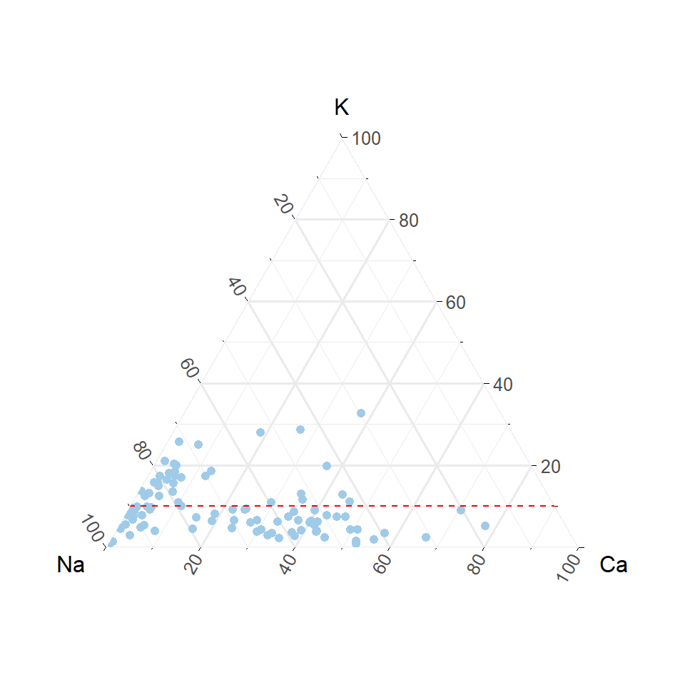

Filter to grains with <sup>87</sup>Rb/<sup>86</sup>Sr < 0.3, and with a K molar abundance < 10%, the calculate a weighted mean <sup>87</sup>Sr/<sup>86</sup>Sr ratio:

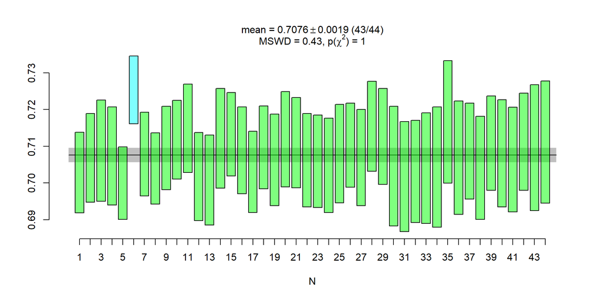

```r
plag_screened <- plag %>% filter(StdCorr_Rb87_Sr86s_mean < 0.3)
plag_screened <- subset(plag_screened, K39_ppm_mean / (K39_ppm_mean + Na23_ppm_mean + Ca43_ppm_mean) < 0.1)

wmean <- IsoplotR::weightedmean(
  x = as.matrix(plag_screened[, c("StdCorr_Sr87s_Sr86s_mean", "Sr87s_Sr86s_1SE_int")]),
  oerr = 2
)
```

Regional initial 87Sr/86Sr ratio from 43 plagioclase grains: 0.7076078 ± 0.0019422.

(101 measured, filtered to 44 with <sup>87</sup>Rb/<sup>86</sup>Sr < 0.3, 1 outlier(s) rejected from the weighted mean.)

## Screen K-feldspar grains

Check no K-feldspar grains have suspicious major element compositions:

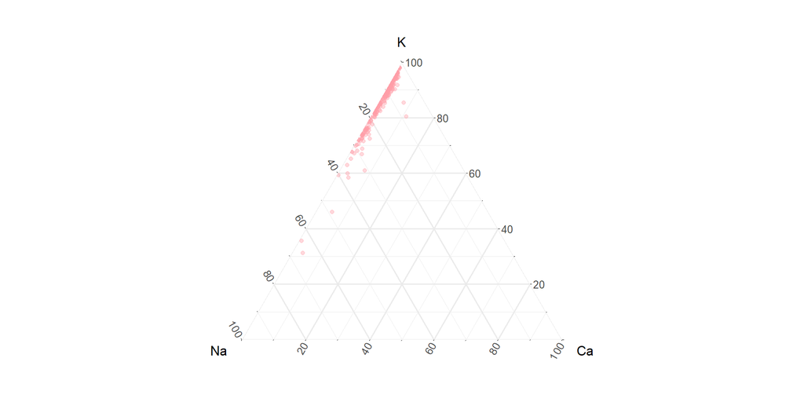

```r
#pdf("kfs_ternary_post.pdf", width = cm(4), height = cm(3))
kfs_ternary <- ggtern(data = rb_sr_df_no_repl, aes(Na23_ppm_mean, K39_ppm_mean, Ca43_ppm_mean)) +
  geom_point(size = 1.5, alpha = 0.4, colour = "#FF9DA7") +
  theme_minimal() +
  Tlab("K") + Llab("Na") + Rlab("Ca")
kfs_ternary
```

Length of K-feldspar dataset: 299.

## Calculate detrital ages

With two-point isochrons anchored to the initial <sup>87</sup>Sr/<sup>86</sup>Sr ratio of 0.7076078 ± 0.0019422 calculated above.

```r
IsoplotR::settings("iratio", "Sr87Sr86", wmean_sr_sr0$val, wmean_sr_sr0$err_2se)

age_results <- IsoplotR::age(
  IsoplotR::read.data(rb_sr_df[Rb_Sr_cols], method = "Rb-Sr", format = 1, ierr = 2),
  isochron = FALSE, exterr = FALSE, i2i = FALSE, projerr = FALSE, oerr = 2
)

age_results <- rename(as_tibble(age_results), age = "t", age_2s_int = "err[t]")

age_results <- age_results %>%
  mutate(
    err2s_ext = prop_ext_errs(age, age_2s_int, rb_sr_df$ext_sys_errs_2rs_partial_sum_sq),
  )

rb_sr_df <- bind_cols(rb_sr_df, age_results)
```

## Validation

### SG-2 (this study)

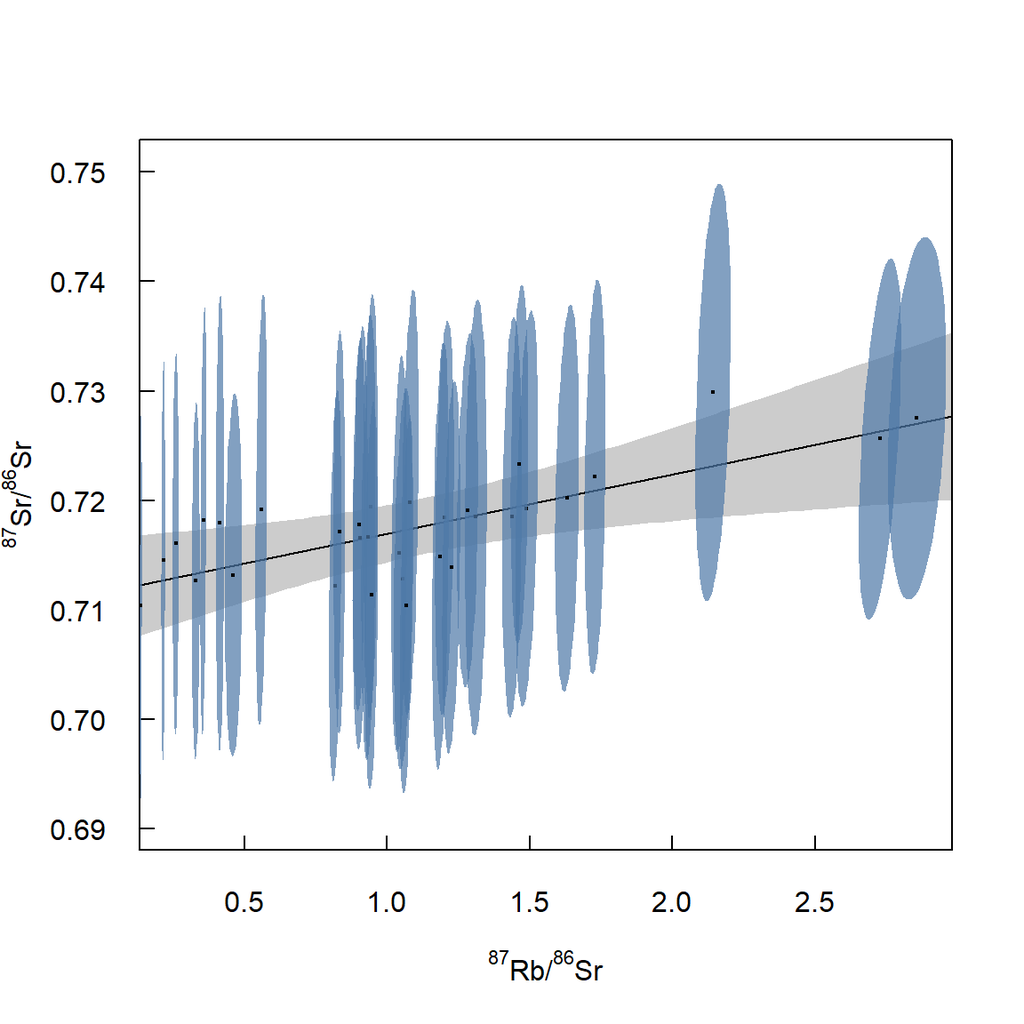

```r
sg2_fsp_df <- bind_rows(filter_data(s1_df, "SG2_Kfs"), filter_data(s1_df, "SG2_Plag"))
sg2_fsp_df <- apply_correction_factor(sg2_fsp_df, s1_corr_factor)

sg2_fsp <- IsoplotR::read.data(sg2_fsp_df[Rb_Sr_cols_calibrated], method = "Rb-Sr", format = 1, ierr = 2)

blue <- "#4e79a7"

sg2_fsp_fit <- IsoplotR::isochron(
  sg2_fsp,
  oerr = 2, exterr = FALSE, title = FALSE,
  ellipse.fill = paste(blue, "B4", sep = ""),
  ellipse.stroke = NA,
  omit = which(sg2_fsp_df$spot_id %in% omitted_spots),
  omit.fill = NA, omit.stroke = blue,
  tck = 0.02, las = 1, xaxs = "i", yaxs = "i"
)
```

```r
sg2_fsp_age <- sg2_fsp_fit$age[1]
sg2_fsp_age_2s_int <- sg2_fsp_fit$age[2] * 2
sg2_fsp_age_2se_ext <- sg2_fsp_age * sqrt(
  (sg2_fsp_age_2s_int / sg2_fsp_age)^2
    + get_session_ext_2rs_sq(s2_msg_fit)
    + get_common_syst_errs_sum_of_sq()
)
```

| SG-2 (Kfs only) |  |
| --- | --- |
| Reference age (Bevan, 2021) | 397.2 ± 2.3 Ma |
| measured age ± 2SE (external) | 387 ± 276 Ma |
| (<sup>87</sup>Sr/<sup>86</sup>Sr)<sub>0</sub> | 0.7115 ± 0.0050 |
| MSWD | 0.19 |
| p(χ2) | 1 |

Very low 87Rb/86Sr values hinder precision in the Shap Granite. In session 2 we instead used a sample of the Dartmoor Granite from Haytor Quarry (HG-1), with much higher 87Rb/86Sr to validate the calibration.

### Recalculate E44794 Haytor West (Darbyshire & Shepherd, 1985)

Reference age is from Darbyshire & Shepherd (1985). Recalculate their sample E44794 isochron with modern decay constant, using the data in their Table 5.

```r
d_and_s_df <- read_csv("data/Darbyshire_Shepherd_Tbl_5.csv")
```

> “Analytical uncertainties are estimated at 0.02% for <sup>87</sup>Sr/<sup>86</sup>Sr and 1.0% for <sup>87</sup>Rb/<sup>86</sup>Sr.”  
> (Darbyshire and Shepherd, 1985, p. 1161)

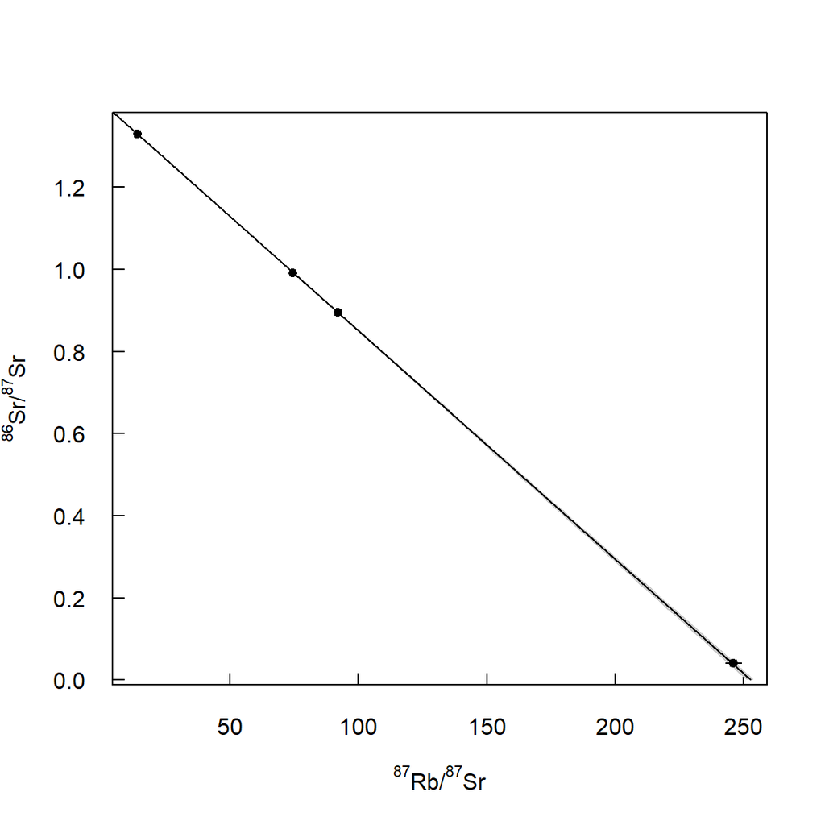

```r
d_and_s_df <- d_and_s_df %>%
  mutate(Sr87s_Sr86_err = 0.02, Rb87_Sr86_err = 1) %>%
  select(Rb87_Sr86, Rb87_Sr86_err, Sr87s_Sr86, Sr87s_Sr86_err)

ds_obj <- IsoplotR::read.data(d_and_s_df, method = "Rb-Sr", format = 1, ierr = 4)

#pdf("E44794_isochron.pdf", width = cm(4), height = cm(4))
ds_fit <- IsoplotR::isochron(
  ds_obj,
  oerr = 2, exterr = TRUE, inverse = TRUE, title = FALSE,
  ellipse.fill = "#E44794",
  tck = 0.02, las = 1, xaxs = "r", yaxs = "r", cex = 0.8
)
```

| E44794 (Haytor West Quarry) |  |
| --- | --- |
| age ± 2SE | 283 ± 3 Ma |
| (<sup>87</sup>Sr/<sup>86</sup>Sr)<sub>0</sub> | 0.7107 ± 0.0005 |
| MSWD | 0.18 |
| p(χ2) | 0.84 |

### HG-1 (this study)

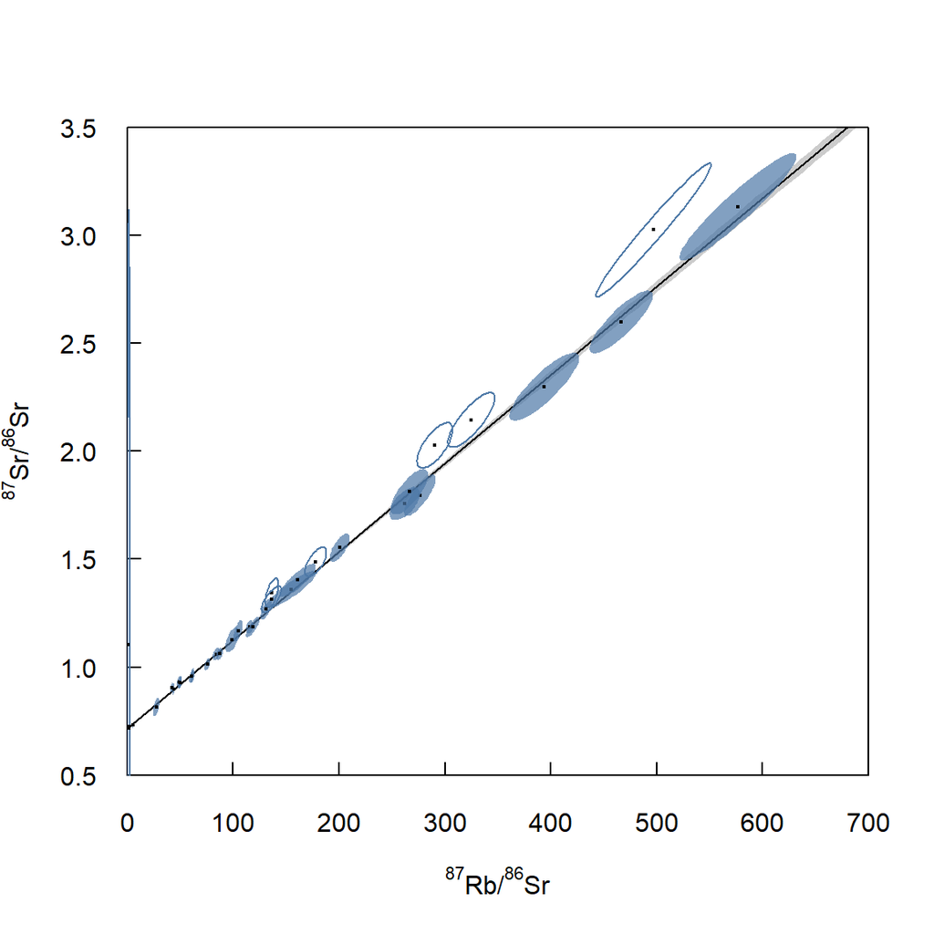

```r
hg1_df <- filter_data(s2_df, "DG2_Fsp") # DG2 was a working name before renaming to HG1
hg1_df <- apply_correction_factor(hg1_df, s2_corr_factor)

hg1_fsp <- IsoplotR::read.data(hg1_df[Rb_Sr_cols_calibrated], method = "Rb-Sr", format = 1, ierr = 2)

blue <- "#4e79a7"
#pdf("HG1_isochron.pdf", width = cm(4), height = cm(4))
hg1_fit <- IsoplotR::isochron(
  hg1_fsp,
  oerr = 2, exterr = FALSE, title = FALSE,
  xlim = c(0, 700), ylim = c(0.5, 3.5),
  ellipse.fill = paste(blue, "B4", sep = ""),
  ellipse.stroke = NA,
  omit = which(hg1_df$spot_id %in% omitted_spots),
  omit.fill = NA, omit.stroke = blue,
  tck = 0.02, las = 1, xaxs = "i", yaxs = "i"
)
```

```r
hg1_age <- hg1_fit$age[1]
hg1_age_2s_int <- hg1_fit$age[2] * 2
hg1_age_2s_ext <- hg1_age * sqrt(
  (hg1_age_2s_int / hg1_age)^2
    + get_session_ext_2rs_sq(s2_msg_fit)
    + get_common_syst_errs_sum_of_sq()
)
```

| HG-1 (Kfs only) |  |
| --- | --- |
| E44794 reference age (recalculated) | 283 ± 3 Ma |
| **HG-1 measured age ± 2SE (external)** | **293 ± 18 Ma** |
| (<sup>87</sup>Sr/<sup>86</sup>Sr)<sub>0</sub> | 0.7148 ± 0.0056 |
| MSWD | 1.22 |
| p(χ2) | 0.21 |